# New Car Sales in Norway by Make

In this project, the monthly car sales in Norway by make from 2007 to 2017 are examined. The public dataset used in this project is used from www.kaggle.com website and the exact link to the dataset is https://www.kaggle.com/dmi3kno/newcarsalesnorway There are five different variables in this dataset as Year (year of sales month/numerical), Month (month of sales make/numerical), Make (car make such as Mazda/categorical), Quantity (number of cars sold/numerical) and Pct (percent share in monthly total/numerical).

# Stage 1

```r
norway<-read_csv("norway_new_car_sales_by_make.csv")
```

```r
str(norway)
```

```
Classes 'spec_tbl_df', 'tbl_df', 'tbl' and 'data.frame':	4367 obs. of  5 variables:
 $ Year    : num  2007 2007 2007 2007 2007 ...
 $ Month   : num  1 1 1 1 1 1 1 1 1 1 ...
 $ Make    : chr  "Toyota" "Volkswagen" "Peugeot" "Ford" ...
 $ Quantity: num  2884 2521 1029 870 693 ...
 $ Pct     : num  22.7 19.9 8.1 6.9 5.5 5.2 4.9 4.7 3.3 2.9 ...
 - attr(*, "spec")=
  .. cols(
  ..   Year = col_double(),
  ..   Month = col_double(),
  ..   Make = col_character(),
  ..   Quantity = col_double(),
  ..   Pct = col_double()
  .. )
```

In the below pie chart, sales in January 2007 by make are shown based on brands market share.

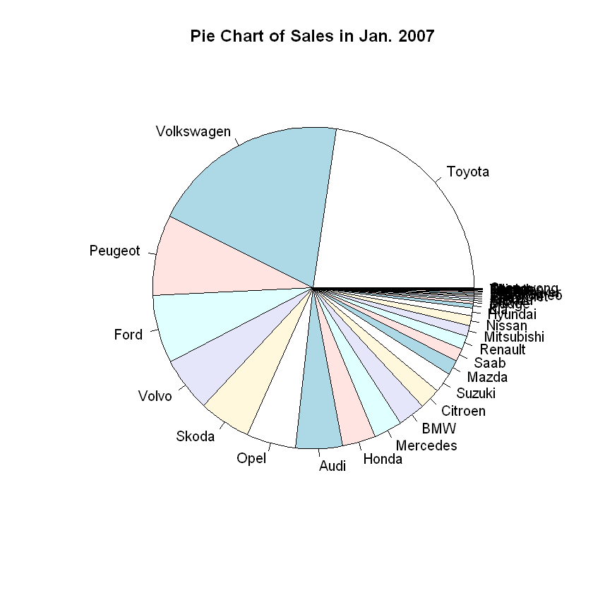

```r
slices <- c(2884, 2521, 1029, 870, 693, 665, 622, 599, 423, 362, 352, 263, 258, 191, 169, 168, 136, 127, 97, 55, 33, 26, 26, 22, 20, 16, 15, 14, 9, 4, 4, 3, 2, 2, 2, 1, 1)
lbls <- c("Toyota", "Volkswagen", "Peugeot", "Ford", "Volvo", "Skoda", "Opel", "Audi", "Honda", "Mercedes", "BMW", "Citroen", "Suzuki", "Mazda", "Saab", "Renault", "Mitsubishi", "Nissan", "Hyundai", "Kia", "Dodge", "MINI", "Subaru", "Lexus", "Chevrolet", "Alfa Romeo", "Daihatsu", "Land Rover", "Fiat", "Chrysler", "Iveco", "Jaguar", "Jeep", "Nilsson", "Think", "Smart", "Ssangyong")

pie(slices, labels = lbls, main="Pie Chart of Sales in Jan. 2007")
```

# Stage 2

```r
#Mean for Year
mean(norway$Year)
```

2011.42546370506

```r
#Mean for Month
mean(norway$Month)
```

6.45935424776735

```r
#Mean for Quantty
mean(norway$Quantity)
```

308.503320357225

```r
#Mean for Pct
mean(norway$Pct)
```

2.76858255095031

```r
#Median for Year
median(norway$Year)
```

2011

```r
#Median for Month
median(norway$Month)
```

6

```r
#Median for Quantity
median(norway$Quantity)
```

155

```r
#Median for Pct
median(norway$Pct)
```

1.4

```r
#Mode for Year
names(table(norway$Year))[table(norway$Year)==max(table(norway$Year))]
```

'2008'

```r
#Mode for Month
names(table(norway$Month))[table(norway$Month)==max(table(norway$Month))]
```

'1'

```r
#Mode for Quantity
names(table(norway$Quantity))[table(norway$Quantity)==max(table(norway$Quantity))]
```

'1'

```r
#Mode for Pct
names(table(norway$Pct))[table(norway$Pct)==max(table(norway$Pct))]
```

'0'

```r
#Measures of Variablity - Variance for Year
var (norway$Year)
```

8.44514164818993

```r
#Measures of Variablity - Variance for Month
var (norway$Month)
```

11.8860594088362

```r
#Measures of Variablity - Variance for Quantity
var (norway$Quantity)
```

169352.296312839

```r
#Measures of Variablity - Variance for Pct
var (norway$Pct)
```

13.2273178025631

```r
#Measures of Variablity - Standard Deviation for Year
sqrt (var (norway$Year))
```

2.90605258868279

```r
#Measures of Variablity - Standard Deviation for Month
sqrt (var (norway$Month))
```

3.44761648227238

```r
#Measures of Variablity - Standard Deviation for Quantity
sqrt (var (norway$Quantity))
```

411.52435688892

```r
#Measures of Variablity - Standard Deviation for Pct
sqrt (var (norway$Pct))
```

3.6369379706785

```r
#Measures of Variablity - Range for Year
range (norway$Year)
max (norway$Year) - min (norway$Year)
```

1. 2007

2. 2017

10

```r
#Measures of Variablity - Range for Month
range (norway$Month)
max (norway$Month) - min (norway$Month)
```

1. 1

2. 12

11

```r
#Measures of Variablity - Range for Quantity
range (norway$Quantity)
max (norway$Quantity) - min (norway$Quantity)
```

1. 1

2. 3017

3016

```r
#Measures of Variablity - Range for Pct
range (norway$Pct)
max (norway$Pct) - min (norway$Pct)
```

1. 0

2. 22.7

22.7

```r
#Measures of Variablity - Mean Deviation for Year
sum (abs (norway$Year - mean(norway$Year))) / length (norway$Year)
```

2.52118934979224

```r
#Measures of Variablity - Mean Deviation for Month
sum (abs (norway$Month - mean(norway$Month))) / length (norway$Month)
```

2.99030706231956

```r
#Measures of Variablity - Mean Deviation for Quantity
sum (abs (norway$Quantity - mean(norway$Quantity))) / length (norway$Quantity)
```

299.025544803337

```r
#Measures of Variablity - Mean Deviation for Pct
sum (abs (norway$Pct - mean(norway$Pct))) / length (norway$Pct)
```

2.66839299828129

```r
#Measures of Variablity - Interquartile Range for Year
IQR (norway$Year)
```

5

```r
#Measures of Variablity - Interquartile Range for Month
IQR (norway$Month)
```

6

```r
#Measures of Variablity - Interquartile Range for Quantity
IQR (norway$Quantity)
```

449

```r
#Measures of Variablity - Interquartile Range for Pct
IQR (norway$Pct)
```

4.1

Mean is used for calculating the average number of the given variables. Median is used for finding the middle number of the given variables. Mode is used for finding the most often used number of the given variables. Based on the information we can see that the variety of different brands sales happend on January. We can also compare the results with different graphs in the notebook and figure out some connections among them.

# Stage 3

```r
qty <- c (norway$Quantity)
pc <- c (norway$Pct)
new.data <- data.frame (qty, pc)
str (new.data)
```

```
'data.frame':	4367 obs. of  2 variables:
 $ qty: num  2884 2521 1029 870 693 ...
 $ pc : num  22.7 19.9 8.1 6.9 5.5 5.2 4.9 4.7 3.3 2.9 ...
```

```r
cor (new.data)
```

|  | qty | pc |
| --- | --- | --- |
| qty | 1.0000000 | 0.9808712 |
| pc | 0.9808712 | 1.0000000 |

```r
install.packages("corrplot")
library(corrplot)
```

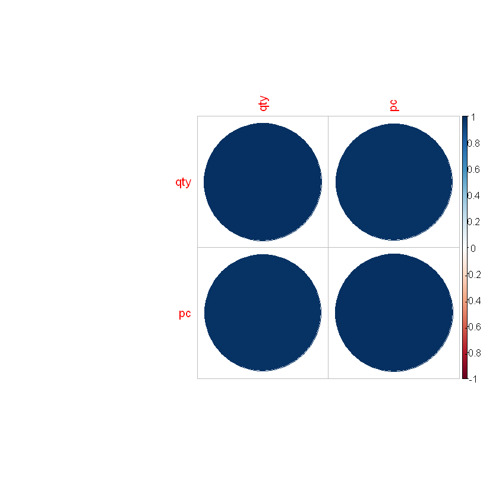

```r
corrplot (cor(new.data))
```

Based on the variables in this project, only two variables of Quantity and Pct have linear relationships between them. New data frame has been created with only two desired variables and correlation matrix has been computed. in order to express it visually, it is needed to install "corrplot" package.

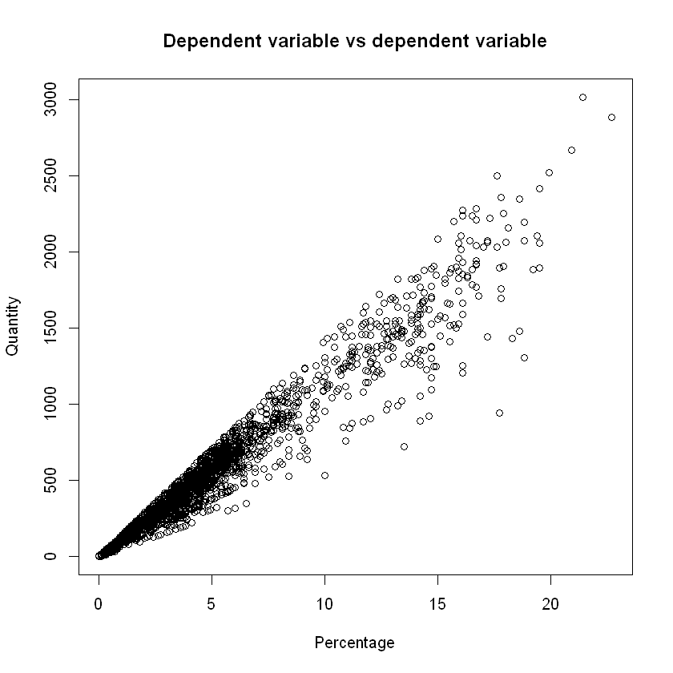

```r
# Scatter plot for dependent variable vs dependent variable
plot (norway$Pct, norway$Quantity, xlab = "Percentage", ylab = "Quantity", main = "Dependent variable vs dependent variable")
```

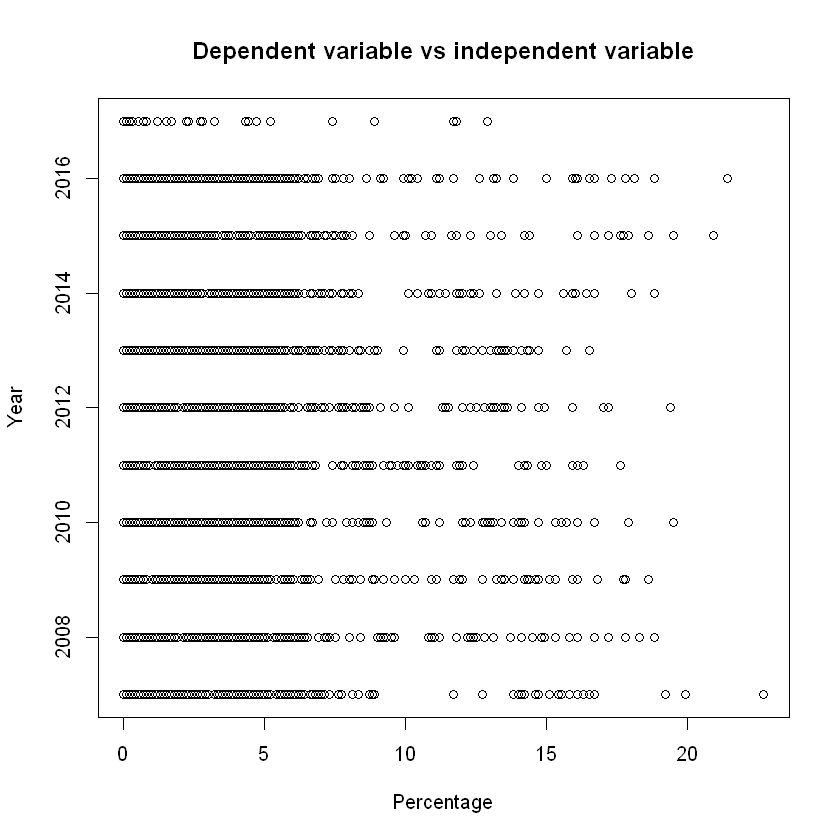

```r
# Scatter plot for dependent variable vs independent variable
plot (norway$Pct, norway$Year, xlab = "Percentage", ylab = "Year", main = "Dependent variable vs independent variable")
```

As it is shown in the scatter plots, dependent variables and independent variables have no linear relationships.

```r
#Linear Regression Model for dependent variable vs independent variable
LinearRegressionModel <- lm(norway$Year ~ norway$Pct, data=norway)
print (LinearRegressionModel)
```

```
Call:
lm(formula = norway$Year ~ norway$Pct, data = norway)

Coefficients:
(Intercept)   norway$Pct
  2.011e+03    2.506e-02
```

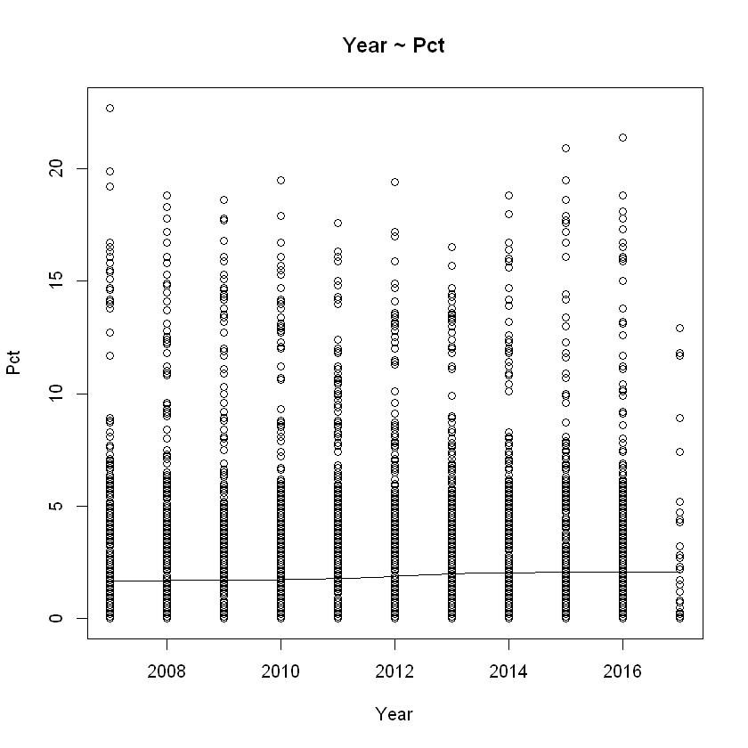

```r
#Scatter plot for dependent variable vs independent variable
scatter.smooth(x=norway$Year, y=norway$Pct, main="Year ~ Pct", xlab = "Year", ylab = "Pct")
```

```r
#Linear Regression Model for dependent variable vs dependent variable
LinearRegressionModel2 <- lm(norway$Quantity ~ norway$Pct, data=norway)
print (LinearRegressionModel2)
```

```
Call:
lm(formula = norway$Quantity ~ norway$Pct, data = norway)

Coefficients:
(Intercept)   norway$Pct
      1.227      110.987
```

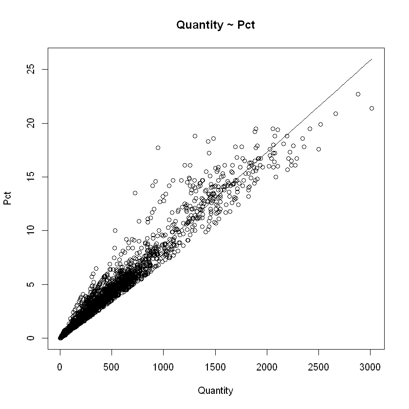

```r
#Scatter plot for dependent variable vs dependent variable
scatter.smooth(x=norway$Quantity, y=norway$Pct, main="Quantity ~ Pct", xlab = "Quantity", ylab = "Pct")
```

# Stage 4

Swedish Lottery The Lotto is by far the most popular game of chance in Sweden. All Swedish Lotto Bets, by default, are for two separate draws, Lotto 1 and Lotto 2, giving you two different chances to win. It costs £0.50 for the Swedish Lotto 1 at or £1 to go for both Lotto 1 and Lotto 2. There are 6 prize tiers for the Swedish Lotto: Matched Numbers Odds of Winning 7 1:6,724,520 6+1 1:240,161 6 1:40,027 5 1:847 4 1:59 3 1:55

Swedish Lotto has no minimum jackpot as prizes are based on official ticket sales. The biggest Drömvinsten(Dream Win) of all time was 237, 697, 528 kr or about £19 million.

# Stage 5

```r
smp <- floor(0.7 * nrow(norway))
set.seed(123)
train_ind <- sample(seq_len(nrow(norway)), size = smp)
training <- norway[train_ind, ]
testing <- norway[-train_ind, ]
```

```r
LinearRegressionModel3 <- lm(training$Quantity ~ training$Pct, data=training)
print (LinearRegressionModel3)
```

```
Call:
lm(formula = training$Quantity ~ training$Pct, data = training)

Coefficients:
 (Intercept)  training$Pct
       1.197       110.865
```

```r
LinearRegressionModel4 <- lm(testing$Quantity ~ testing$Pct, data=testing)
print (LinearRegressionModel4)
```

```
Call:
lm(formula = testing$Quantity ~ testing$Pct, data = testing)

Coefficients:
(Intercept)  testing$Pct
      1.323      111.277
```

```r
install.packages("Metrics")
library("Metrics")
```

```r
mae(actual = LinearRegressionModel3$Pct, predicted = LinearRegressionModel4$Pct)
```

NaN

```r
mape(actual = norway$Pct, predicted = LinearRegressionModel4$Pct)
```

NaN

```r
rmse(actual = LinearRegressionModel3$Pct, predicted = LinearRegressionModel4$Pct)
```

NaN